# Practical Machine Learning: Prediction Assignment

Yun Cheng

November 6, 2016

### Instructions

One thing that people regularly do is quantify how much of a particular activity they do, but they rarely quantify how well they do it. In this project, your goal will be to use data from accelerometers on the belt, forearm, arm, and dumbell of 6 participants.

### What You Should Submit

The goal of your project is to predict the manner in which they did the exercise. This is the “classe” variable in the training set. You may use any of the other variables to predict with. You should create a report describing how you built your model, how you used cross validation, what you think the expected out of sample error is, and why you made the choices you did. You will also use your prediction model to predict 20 different test cases.

### Load Data

```r
library(data.table)
library(caret)
library(rattle)
library(rpart)
library(rpart.plot)
library(randomForest)
library(klaR)
library(gbm)

training.data <- read.csv("https://d396qusza40orc.cloudfront.net/predmachlearn/pml-training.csv")
predict.data <- read.csv("https://d396qusza40orc.cloudfront.net/predmachlearn/pml-testing.csv")
```

### Remove Redundant Features

```r
#remove variables with Nearly Zero Variance
NZV <- nearZeroVar(training.data)
training.1 <- training.data[, -NZV]
predict.1 <- predict.data[, -NZV]
```

```r
#remove variables that are mostly NA
ALLNA <- sapply(training.1, function(x) mean(is.na(x))) > 0.95
training.2 <- training.1[, ALLNA==FALSE]
predict.2 <- predict.1[, ALLNA==FALSE]
```

```r
#remove identification only variables (columns 1 to 5)
training.3 <- training.2[, -(1:5)]
predict.3 <- predict.2[, -(1:5)]
```

### Create Training And Test Datasets

```r
#select random sample to build as traing and test data (to shorten time consuming)
set.seed(2000)
training.s <- data.frame(data.table(training.3)[sample(.N,1000)])

#create training and test datasets
inTrain <- createDataPartition(y=training.s$classe,p=0.7,list=FALSE)
training <- training.s[inTrain,]
test <- training.s[-inTrain,]
dim(training); dim(test)
```

```
## [1] 703  54
```

```
## [1] 297  54
```

### Machine Learning Classifier

#### a. Decision Tree

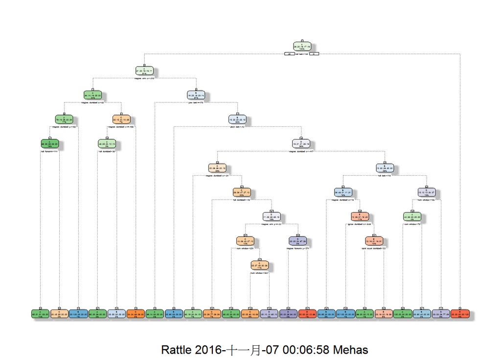

```r
#decision tree model
modfit.1 <- rpart(classe ~., method="class", data = training)
fancyRpartPlot(modfit.1)
```

```r
#decision tree model prediction
predict.1 <- predict(modfit.1, newdata=test, type="class")
confusion.1 <- confusionMatrix(predict.1, test$classe)
confusion.1
```

```
## Confusion Matrix and Statistics
##
##           Reference
## Prediction  A  B  C  D  E
##          A 73  5  6  6  4
##          B  3 30  4  1  4
##          C  0  9 30 14  8
##          D  1  5  7 24  5
##          E  7 10  1  4 36
##
## Overall Statistics
##
##                Accuracy : 0.6498
##                  95% CI : (0.5926, 0.704)
##     No Information Rate : 0.2828
##     P-Value [Acc > NIR] : < 2.2e-16
##
##                   Kappa : 0.5558
##  Mcnemar's Test P-Value : 0.003822
##
## Statistics by Class:
##
##                      Class: A Class: B Class: C Class: D Class: E
## Sensitivity            0.8690   0.5085   0.6250  0.48980   0.6316
## Specificity            0.9014   0.9496   0.8755  0.92742   0.9083
## Pos Pred Value         0.7766   0.7143   0.4918  0.57143   0.6207
## Neg Pred Value         0.9458   0.8863   0.9237  0.90196   0.9121
## Prevalence             0.2828   0.1987   0.1616  0.16498   0.1919
## Detection Rate         0.2458   0.1010   0.1010  0.08081   0.1212
## Detection Prevalence   0.3165   0.1414   0.2054  0.14141   0.1953
## Balanced Accuracy      0.8852   0.7290   0.7503  0.70861   0.7700
```

#### b. Random Forests

```r
#random forests model
modfit.2 <- train(classe ~ ., data = training, method="rf", Prox=TRUE)
modfit.2$finalModel
```

```
##
## Call:
##  randomForest(x = x, y = y, mtry = param$mtry, Prox = TRUE)
##                Type of random forest: classification
##                      Number of trees: 500
## No. of variables tried at each split: 27
##
##         OOB estimate of  error rate: 9.82%
## Confusion matrix:
##     A   B   C  D   E class.error
## A 192   2   1  2   1  0.03030303
## B  10 119   8  2   0  0.14388489
## C   0   7 103  5   0  0.10434783
## D   1   1  14 97   3  0.16379310
## E   1   5   3  3 123  0.08888889
```

```r
#random forests model prediction
predict.2 <- predict(modfit.2$finalModel, newdata=test, type="class")
confusion.2 <- confusionMatrix(predict.2, test$classe)
confusion.2
```

```
## Confusion Matrix and Statistics
##
##           Reference
## Prediction  A  B  C  D  E
##          A 81  6  0  1  1
##          B  2 46  5  2  0
##          C  0  5 43  4  1
##          D  1  1  0 41  3
##          E  0  1  0  1 52
##
## Overall Statistics
##
##                Accuracy : 0.8855
##                  95% CI : (0.8437, 0.9194)
##     No Information Rate : 0.2828
##     P-Value [Acc > NIR] : < 2.2e-16
##
##                   Kappa : 0.8549
##  Mcnemar's Test P-Value : NA
##
## Statistics by Class:
##
##                      Class: A Class: B Class: C Class: D Class: E
## Sensitivity            0.9643   0.7797   0.8958   0.8367   0.9123
## Specificity            0.9624   0.9622   0.9598   0.9798   0.9917
## Pos Pred Value         0.9101   0.8364   0.8113   0.8913   0.9630
## Neg Pred Value         0.9856   0.9463   0.9795   0.9681   0.9794
## Prevalence             0.2828   0.1987   0.1616   0.1650   0.1919
## Detection Rate         0.2727   0.1549   0.1448   0.1380   0.1751
## Detection Prevalence   0.2997   0.1852   0.1785   0.1549   0.1818
## Balanced Accuracy      0.9634   0.8709   0.9278   0.9083   0.9520
```

#### c. Boosting

```r
#boosting model
modfit.3 <- train(classe ~ ., data = training, method="gbm", verbose=FALSE)
```

```r
#boosting model prediction
predict.3 <- predict(modfit.3, newdata=test)
confusion.3 <- confusionMatrix(predict.3, test$classe)
confusion.3
```

```
## Confusion Matrix and Statistics
##
##           Reference
## Prediction  A  B  C  D  E
##          A 80  6  0  2  0
##          B  3 45  3  1  1
##          C  0  5 42  4  1
##          D  0  1  3 40  3
##          E  1  2  0  2 52
##
## Overall Statistics
##
##                Accuracy : 0.8721
##                  95% CI : (0.8286, 0.9078)
##     No Information Rate : 0.2828
##     P-Value [Acc > NIR] : < 2.2e-16
##
##                   Kappa : 0.8379
##  Mcnemar's Test P-Value : NA
##
## Statistics by Class:
##
##                      Class: A Class: B Class: C Class: D Class: E
## Sensitivity            0.9524   0.7627   0.8750   0.8163   0.9123
## Specificity            0.9624   0.9664   0.9598   0.9718   0.9792
## Pos Pred Value         0.9091   0.8491   0.8077   0.8511   0.9123
## Neg Pred Value         0.9809   0.9426   0.9755   0.9640   0.9792
## Prevalence             0.2828   0.1987   0.1616   0.1650   0.1919
## Detection Rate         0.2694   0.1515   0.1414   0.1347   0.1751
## Detection Prevalence   0.2963   0.1785   0.1751   0.1582   0.1919
## Balanced Accuracy      0.9574   0.8645   0.9174   0.8941   0.9457
```

#### d. Linear Discriminant Analysis

```r
#linear discriminant analysis model
modfit.4 <- train(classe ~ ., data=training, method="lda")
```

```r
#linear discriminant analysis model prediction
predict.4 <- predict(modfit.4, newdata=test)
confusion.4 <- confusionMatrix(predict.4, test$classe)
confusion.4
```

```
## Confusion Matrix and Statistics
##
##           Reference
## Prediction  A  B  C  D  E
##          A 66 10  5  4  1
##          B  3 32  8  3  7
##          C  5  9 25  8  3
##          D  6  1 10 33  9
##          E  4  7  0  1 37
##
## Overall Statistics
##
##                Accuracy : 0.6498
##                  95% CI : (0.5926, 0.704)
##     No Information Rate : 0.2828
##     P-Value [Acc > NIR] : < 2e-16
##
##                   Kappa : 0.5573
##  Mcnemar's Test P-Value : 0.08247
##
## Statistics by Class:
##
##                      Class: A Class: B Class: C Class: D Class: E
## Sensitivity            0.7857   0.5424  0.52083   0.6735   0.6491
## Specificity            0.9061   0.9118  0.89960   0.8952   0.9500
## Pos Pred Value         0.7674   0.6038  0.50000   0.5593   0.7551
## Neg Pred Value         0.9147   0.8893  0.90688   0.9328   0.9194
## Prevalence             0.2828   0.1987  0.16162   0.1650   0.1919
## Detection Rate         0.2222   0.1077  0.08418   0.1111   0.1246
## Detection Prevalence   0.2896   0.1785  0.16835   0.1987   0.1650
## Balanced Accuracy      0.8459   0.7271  0.71022   0.7843   0.7996
```

#### e. Naive Bayes

```r
#naive bayes model
modfit.5 <- train(classe ~ ., data = training, method="nb")
```

```r
#naive bayes model prediction
predict.5 <- predict(modfit.5, newdata=test)
confusion.5 <- confusionMatrix(predict.5, test$classe)
confusion.5
```

```
## Confusion Matrix and Statistics
##
##           Reference
## Prediction  A  B  C  D  E
##          A 56  6  2  2  0
##          B  3 33  4  3  3
##          C  7  9 32 14  5
##          D 12  5 10 23  4
##          E  6  6  0  7 45
##
## Overall Statistics
##
##                Accuracy : 0.6364
##                  95% CI : (0.5788, 0.6912)
##     No Information Rate : 0.2828
##     P-Value [Acc > NIR] : < 2.2e-16
##
##                   Kappa : 0.5446
##  Mcnemar's Test P-Value : 0.002772
##
## Statistics by Class:
##
##                      Class: A Class: B Class: C Class: D Class: E
## Sensitivity            0.6667   0.5593   0.6667  0.46939   0.7895
## Specificity            0.9531   0.9454   0.8594  0.87500   0.9208
## Pos Pred Value         0.8485   0.7174   0.4776  0.42593   0.7031
## Neg Pred Value         0.8788   0.8964   0.9304  0.89300   0.9485
## Prevalence             0.2828   0.1987   0.1616  0.16498   0.1919
## Detection Rate         0.1886   0.1111   0.1077  0.07744   0.1515
## Detection Prevalence   0.2222   0.1549   0.2256  0.18182   0.2155
## Balanced Accuracy      0.8099   0.7524   0.7631  0.67219   0.8552
```

### Compare Model Accuracy

- decision tree: 0.6498
- random forests: 0.8855
- boosting: 0.8721
- linear discriminant analysis: 0.6498
- naive bayes: 0.6364 Select random forests model to predict test dataset

### Apply The Selected Model to predict test dataset

```r
#select random forests model to predict test dataset
Predict <- predict(modfit.2, newdata=predict.data)
Predict
```

```
##  [1] B A C A A E D D A A A C B A E E A A B B
## Levels: A B C D E
```